# Common problems with lab 1

Generally, the use of Rmarkdown was very good. But…

1. Pay attention to the options specified in your R code chunks. These dictate the output that is printed to the HTML file. For instance, if your chunk includes `{r, eval = FALSE}` then the code within the chunk will not be evaluated when you knit the HMTL.
   1. `eval`: should Rmarkdown evaluate the R code?
   2. `echo`: should Rmarkdown print the R code to the HTML?
   3. `warning`: should Rmarkdown report warning messages in the HTML?

For a full list of the options that can be passed to these chunks, see the Rmarkdown cheat sheet (`help -> cheetsheets -> R markdown cheet sheet`).

2. Please sumbit the HTML file produced by Rmarkdown, not the `.Rmd` file. There is no point learning how to make beautiful reports if you are just going to show us the code!
3. In question c.iii, lots of people struggled with producing the correct boxplot. Mostly this was because people forgot that when using `plot(x,y)`, if you give R a continuous variable for `x` then R will think that you want to see a scatterplot. Give R a categorical variable for `x` and you will get the required boxplot. See James et al p. 50 for more on this.
4. Visualising your data is an important part of understanding your data. R provides powerful tools for visualisation (see `ggplot` for one popular method), but even the `base` R plotting functions can be very good. In particular, the `plot` function can take a number of arguments which can be used to improve on the ugliness of the default settings. Among others, you should check out and become familair with:
   1. `cex`
   2. `col` and `pch`
   3. `ylab` and `xlab`
   4. `main`

For example, consider the difference between:

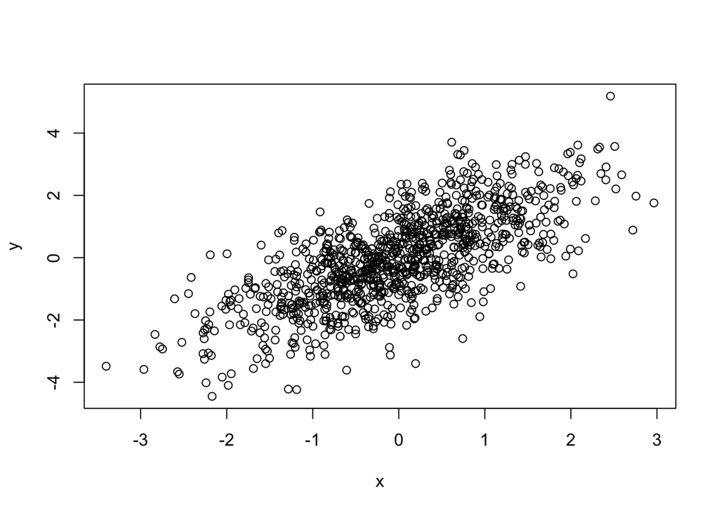

```r
x <- rnorm(1000)
y <- rnorm(1000,mean = x)
plot(x, y)
```

and

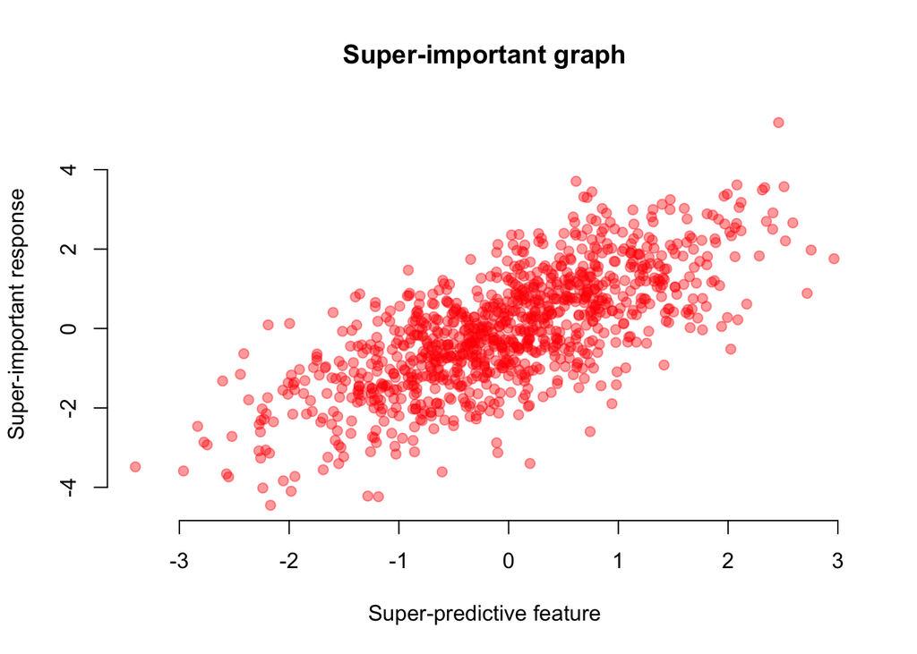

```r
library(scales)
plot(x, y, bty= "n", xlab = "Super-predictive feature", ylab = "Super-important response", main = "Super-important graph", col = alpha("red", 0.4), pch = 19)
```

5. When calculating summary statistics (mean, sd, etc) for a number of different variables, you can use the `sapply` function to “loop” over the variables you are interested in:

Rather than:

```r
mean(Auto$cylinders)
```

```
## [1] 5.471939
```

```r
mean(Auto$horsepower)
```

```
## [1] 104.4694
```

```r
mean(Auto$acceleration)
```

```
## [1] 15.54133
```

Try:

```r
#Pulling together qualitative predictors
qualitative_columns <- which(names(Auto) %in% c("name", "origin", "originf"))

# Apply the range function to the columns of Auto data
# that are not qualitative
sapply(Auto[, -qualitative_columns], mean)
```

```
##          mpg    cylinders displacement   horsepower       weight
##    23.445918     5.471939   194.411990   104.469388  2977.584184
## acceleration         year
##    15.541327    75.979592
```